[figure not shown]

```python
from IPython.display import Image
Image(filename="Images/banner_data_quality.png")
```

# Pipeline MLOPS - Planta de Beneficiamento de Minério de Cobre

**Informações Sobre o Documento**

**Projeto:** Otmização da Dosagem de Reagentes na Flotação.  
**Localização:** Municípios de Craíbas e Arapiraca, Estado de Alagoas.  
**Metodologia:** CRISP-DM.  
**Fase da Metodologia:** Deployment.  
**Entregável:** Documentação MLOPS

## 1. Primeiros Passos

This section explains the first steps to set up and explore Kedro:

- Estrutura do Projeto
- Set up the virtual environment using Anaconda
- Set up project requirements via requirements.txt

#### 1.1 Estrutura do Projeto

Este documento descreve a estrutura de pastas e arquivos adotada no projeto, seguindo o padrão proposto pelo [Kedro](https://kedro.readthedocs.io/en/stable/). Essa organização visa proporcionar uma fácil manutenção, escalabilidade e compreensão do projeto. Cada seção representa um componente crucial do projeto, abrangendo desde configurações até a implementação do código fonte.

A estrutura de pastas e arquivos adotada segue as melhores práticas sugeridas pelo Kedro, proporcionando uma organização lógica e intuitiva para o projeto. Isso facilita a colaboração, manutenção e expansão futura do código fonte. Recomenda-se a familiarização com esta estrutura para otimizar a eficiência durante o desenvolvimento e manutenção do projeto.

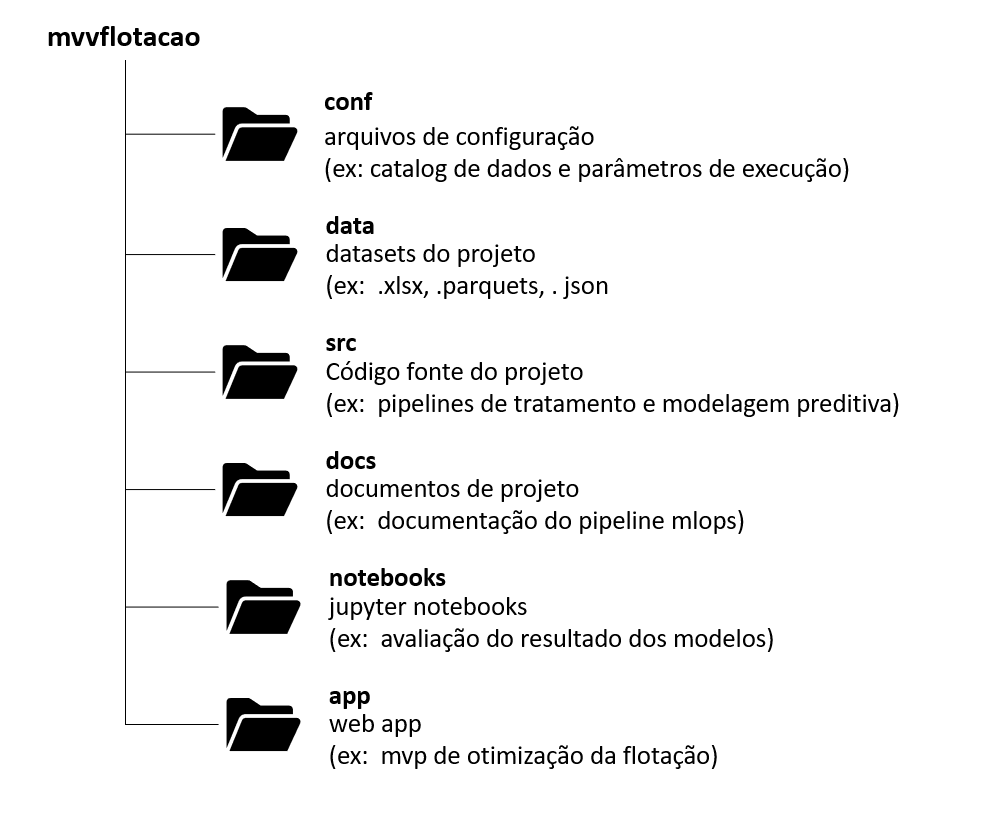

```python
Image(filename="Images/Estrutura de Pastas.png",width = 500)
```

##### 1.1.1 **conf**

A pasta `conf` contém todos os arquivos relacionados à configuração do projeto. Isso inclui o catalog de dados e parâmetros de execução. Os arquivos presentes nesta pasta desempenham um papel fundamental na definição e personalização de aspectos operacionais do projeto.

Exemplos de arquivos nesta pasta:

- `catalog.yml`: Descreve os datasets disponíveis e suas fontes.
- `parameters.yml`: Armazena parâmetros de execução, facilitando a flexibilidade e reusabilidade do código.

##### 1.1.2 **data**

A pasta `data` é dedicada ao armazenamento de datasets utilizados no projeto. Diferentes tipos de dados, como arquivos `.xlsx`, `.parquet` e `.json`, podem ser encontrados aqui.

Estrutura de exemplo:

```
plaintext
data/
|-- raw/
|   |-- dataset_raw.xlsx
|-- processed/
|   |-- dataset_processed.parquet
|-- external/
|   |-- external_data.json
```

##### 1.1.3 **src**

A pasta `src` contém todo o código fonte do projeto. As subpastas organizam o código de acordo com suas funcionalidades, tornando mais fácil a navegação e manutenção do código.

Exemplos de subpastas:

- `pipelines/`: Contém scripts relacionados a pipelines de tratamento e modelagem preditiva.

##### 1.1.4 **docs**

A pasta `docs` é destinada à documentação do projeto. Aqui, você encontrará informações detalhadas sobre o pipeline MLOps, instruções de uso e qualquer outra documentação relevante.

##### 1.1.5 **notebooks**

A pasta `notebooks` abriga todos os Jupyter Notebooks utilizados durante o desenvolvimento do projeto. Esses notebooks podem incluir análises exploratórias, avaliação de resultados de modelos e outros experimentos.

##### 1.1.6 **app**

A pasta `app` contém o código fonte do aplicativo web associado ao projeto. No exemplo fornecido, um MVP para otimização da flotação está presente.

Estrutura de exemplo:

```
plaintext
app/
|-- static/
|-- templates/
|-- app.py
```

#### 1.2 Criação de um ambiente virtual via Conda

Para garantir a consistência do ambiente de desenvolvimento, recomenda-se a criação de um ambiente virtual específico para o projeto usando o [Kedro](https://kedro.readthedocs.io/en/stable/) como referência.

##### 1.2.1 **Instalação do Conda**

Se você ainda não utiliza o Conda como gerenciador de ambientes virtuais, recomenda-se instalá-lo seguindo as instruções em [Conda Installation](https://docs.conda.io/projects/conda/en/latest/user-guide/install/index.html).

##### 1.2.2 **Criação de um Novo Ambiente Virtual com Conda**

```
# Substitua `my_kedro_env` pelo nome que deseja dar ao ambiente virtual
conda create --name my_kedro_env python=3.7

# Ative o ambiente virtual
conda activate my_kedro_env
```

Ao executar esses comandos, você terá criado um ambiente virtual isolado com o nome my_kedro_env e o Python 3.7 instalado. Certifique-se de ativar o ambiente virtual sempre que estiver trabalhando no projeto

##### 1.2.2 **Instalação das Dependências do Projeto**

Certifique-se de estar na raiz do projeto antes de executar os comandos a seguir.

```
# Instale as dependências do projeto a partir do arquivo requirements.txt
pip install -r src/requirements.txt

# Inicialize o projeto Kedro
kedro install
```

Ao seguir esses passos, você terá configurado um ambiente virtual com Conda e instalado as dependências do projeto, conforme as melhores práticas do Kedro. Certifique-se de manter o arquivo requirements.txt atualizado à medida que novas dependências forem adicionadas ao projeto. Isso garantirá consistência entre ambientes de desenvolvimento.

## 2 Fluxo do Projeto

O fluxo do projeto abrange diversas etapas, desde o processamento de novos dados até a atualização do Simulador MVP. Cada fase desempenha um papel crucial no desenvolvimento, calibração e otimização dos modelos preditivos. A seguir, detalhamos cada uma dessas etapas:

#### 2.1 Processamento de Novos Dados

Nesta fase, os dados recém-coletados ou atualizados são processados e integrados ao projeto. Isso inclui a validação, limpeza e transformação dos dados para garantir sua qualidade e utilidade nos modelos preditivos.

#### 2.2 Calibração dos Modelos Preditivos

A etapa de calibração é dedicada ao ajuste fino dos modelos preditivos. Os algoritmos são treinados utilizando conjuntos de dados históricos, refinando seus parâmetros para melhor se adaptarem às características específicas do sistema em questão.

#### 2.3 Otimização dos Hiperparâmetros dos Modelos Preditivos

Nesta fase, são realizados experimentos para encontrar os melhores hiperparâmetros dos modelos preditivos. Isso envolve a busca por combinações ideais que maximizem o desempenho do modelo.

#### 2.4 Verificação da Variável que Captura Mudanças na Dinâmica do Processo

A variável que captura mudanças na dinâmica do processo é analisada para identificar padrões e comportamentos significativos. Essa análise contribui para a compreensão da dinâmica do sistema e pode levar a ajustes nos modelos.

#### 2.5 Análise de Erro/Performance

A análise de erro e desempenho dos modelos é essencial para avaliar a qualidade das previsões. Métricas como precisão, recall, e erro médio são examinadas para garantir que os modelos atendam aos critérios de desempenho estabelecidos.

#### 2.6 Exportação do Modelo Preditivo

Os modelos preditivos calibrados e otimizados são exportados para serem utilizados em ambientes de produção. Esta etapa envolve a preparação dos modelos para implementação em escala real.

#### 2.7 Atualização do Simulador MVP

O Simulador MVP é atualizado com os resultados dos modelos preditivos mais recentes. Isso garante que o simulador reflita as mudanças e melhorias identificadas durante o desenvolvimento do projeto.

Cada uma dessas etapas é fundamental para o sucesso do projeto, contribuindo para a criação de modelos preditivos precisos e eficazes, bem como aprimorando continuamente o Simulador MVP.